# R bootcamp - part 2: visualisation with ggplot2

Hannah Meyer

September 2025

# 1 Background: Antigenic cartography

Antigenic Cartography is the process of creating maps that reflect the antigenic properties of a pathogen. In this course, we will use antigenic cartography data used to visualise and quantify the antigenic evolution of influenza viruses.

To create antigenic maps, measurements of laboratory binding assays are converted to a coordinate space in which the distance between points reflects their similarity in the original assay. For instance, to create an antigenic map of influenza viruses, viruses can be titrated against sera in a hemagglutination inhibition (HI) assay. The HI assay tests the ability of influenza viruses to agglutinate red blood cells and the ability of antisera raised against the same or related strains to block this agglutination. Sera with similar abilites to block agglutination will be close together in the antigenic map and simiarly, antigens with similar titers will be nearby in antigenic space.

[Smith *et al* (2004)](https://science.sciencemag.org/content/305/5682/371) mapped the antigenic evolution of human influenza A (H3N2) viruses, which have been a major cause of influenza epidemics since the 1968 Hong Kong influenza pandemic Smith et al. (2004). We will use their antigenic cooridinates of viruses that circulated world-wide circulation between 1968 and 2003, which generated the following map:

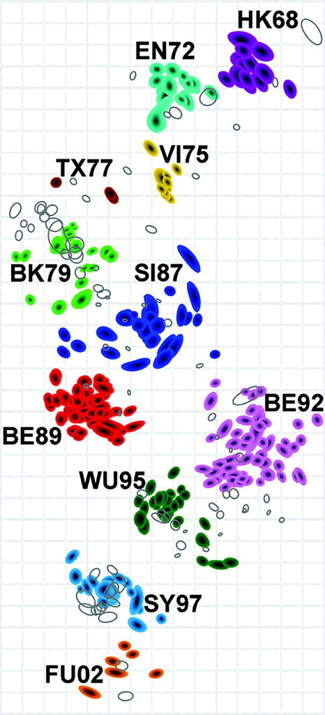

At the end of this course, you will be able to recreate this map, plot the distribution of measurement counts over time and visualise the location that viruses were isolated on a word map.

# 2 Setting up

## 2.1 Starting an Rproject for your analysis

First, we will set up a project, where you will keep all files associated with that project - including your analysis reports, input data, results and figures.

- In R studio click *File > New Project*.
- Choose *Existing directory*, then click on *Browse* to find the folder that you created with the course material
- Click *Create Project*

In your files plane in R studio you can now see all the files you downloaded for this workshop. We will be able to easily read them into R and save results there.

**Note**: There are other ways of specifying the folders from which you read and where you write results and save plots to, but I would highly recommend this strategy. It keeps everything neat and you have all the important parts of your analysis in one place.

When you start your own analysis (independent of this tutorial), follow the scheme above:

- create a projects in R
- choose *Existing directory*, then click on *Browse* to find the folder with your data
- Click *Create Project*

To generate a new file for you analysis:

- choose *File > New File*
- select:
  - *R Markdown* for a file like the one you are looking at i.e. with text and code chunks interleaved
  - *R Script* for a file that only contains plain code, i.e. no need for chunks as the entire file is one big chunk!

## 2.2 Starting an Rproject for your own analysis: some additional advice

- Have a look at this [blog post](https://nicercode.github.io/blog/2013-04-05-projects/), with more advice on the structure and sub-folders in your project directory.
- Rstudio provides a number of cheat sheets for the RStudio interface setup, R Markdown etc. To acces them, choose *Help > Cheatsheets*:
  - RStudio IDE Cheat Sheet
  - R Markdown Cheat Sheet

## 2.3 Customising RStudio settings

RStudio can be customised and I leave this to everyone to figure out what works best. However, I would recommend changing one default setting, which will ensure that when you start working in your project, you start of with a clean slate and none of previously computed data sticks around and confuses your analysis.

- on **Mac OS**:
  - go to *RStudio > Preferences*
  - in *General* untick *restore .RData into workspace at startup*.
- on **Windows** and **Linux**:
  - go to *RStudio > Tools*
  - in *global options* untick *restore .RData into workspace at startup*.

We are all set now to go ahead with your first analysis and data visualisation in R!

## 2.4 Setting up an analysis report

The document you are looking at right now is a R Notebook. R Notebooks allow us to interleaf text describing our analysis with the R code that actually contains the analyses commands.

The text follows some simple markdown rules (for instance bold header sections etc, which we will not go into detail here). Important for us at this stage is that whenever we want to include analysis code into the document, we have to create an R code *chunk*. To include a new *chunk* click the *Insert* button at the top of your editor window and select *R*.

All code *chunks* have some default settings, concerning their layout, execution etc, which can be heavily customised. For our beginners tutorial, we do not have to worry about all of these. I mention this here, as the following and first chunk of our document contains some basic options that I want to have applied to all chunks in the rest of the document. Specifically, it tells R studio that when I prepare this document for sharing with you as a pdf, that I want both the actual code and the results displayed in the document. It also specifies the width and alignment of the figures in the final document.

[output not shown]

[output not shown]

[output not shown]

[output not shown]

[output not shown]

[output cut: 41 more lines]

[output not shown]

[output not shown]

`ggplot2` automatically assign a unique color level to each unique value of cluster. This assigment process is called scaling. Depending on data and aesthetic, `ggplot2` selects a reasonable scale and constructs a legend that explains the mapping between levels and variable values, in this case color and cluster. However, we can also provide our own color-scheme.